# Práctica2: Tipología

J.A. Ubieto y J. Lladó

Diciembre 2020

# 0. Introducción

# 1. Actividad práctica 2

## 1.1. Descripción

La siguiente actividad se realizará un caso práctico de tratamiento de conjunto de datos (dataset) que puede ser el creado en la práctica 1 anterior o bien cualquier dataset libre disponible en Kaggle (https://www.kaggle.com). El objetivo principal es aprender a identificar los datos relevantes para un proyecto analítico y utilizar las herramientas de integración, limpieza, validación y análisis de las mismas que aporta la programación con R.

## 1.2. Objetivos

Los objetivos concretos de esta práctica son:

● Aprender a aplicar los conocimientos adquiridos y su capacidad de resolución de problemas en entornos nuevos o poco conocidos dentro de contextos más amplios o multidisciplinares.

● Saber identificar los datos relevantes y los tratamientos necesarios (integración, limpieza y validación) para llevar a cabo un proyecto analítico.

● Aprender a analizar los datos adecuadamente para abordar la información contenida en los datos.

● Identificar la mejor representación de los resultados para aportar conclusiones sobre el problema planteado en el proceso analítico.

● Actuar con los principios éticos y legales relacionados con la manipulación de datos en función del ámbito de aplicación.

● Desarrollar las habilidades de aprendizaje que les permitan continuar estudiando de un modo que tendrá que ser en gran medida autodirigido o autónomo.

● Desarrollar la capacidad de búsqueda, gestión y uso de información y recursos en el ámbito de la ciencia de datos.

## 1.3. Competencias

En esta práctica se desarrollan las siguientes competencias del Máster de Data Science:

● Capacidad de analizar un problema en el nivel de abstracción adecuado a cada situación y aplicar las habilidades y conocimientos adquiridos para abordarlo y resolverlo.

● Capacidad para aplicar las técnicas específicas de tratamiento de datos (integración, transformación, limpieza y validación) para su posterior análisis.

# 2. Desarrollo de la práctica

Para la realización de la práctica se escogió la base de datos winequality-red que se encuentra en el repositorio www.kaggle.com (https://www.kaggle.com/uciml/red-wine-quality-cortez-et-al-2009). La información proporcionada en la web sobre esta base de datos es la siguiente:

> “Los dos conjuntos de datos están relacionados con variantes tinto y blanco del vino portugués”Vinho Verde“. Para más detalles, consulte la referencia [Cortez et al., 2009]. Debido a cuestiones de privacidad y logística, solo están disponibles las variables fisicoquímicas (entradas) y sensoriales (la salida) (por ejemplo, no hay datos sobre tipos de uva, marca de vino, precio de venta del vino, etc.). Estos conjuntos de datos pueden verse como tareas de clasificación o regresión. Las clases están ordenadas y no equilibradas (por ejemplo, hay vinos mucho más normales que excelentes o malos).”

Después de observar el archivo de la base de datos, solo hay un único archivo .csv referente a los datos de los distintos vinos rojos. Esta base de datos está formada por 12 atributos y un total de 1599 entradas. (El siguiente estudio se podría ampliar buscando la base de datos de vino blanco).

## 2.1. Descripción de los datos

Se procede a la descripción de los distintos atributos de la base de datos winequality-red.csv. Las variables de entrada, basadas en test físico-químicos [Cortez et al., 2009] son:

**fixed_acidity:** conjunto de los ácidos naturales procedentes de la uva (tartárico, málico, cítrico y succínico) o formados en la fermentación maloláctica (láctico). … Sumada a la acidez volátil, da como resultado la acidez total de un vino. (tartaric acid - g / dm^3)

**volatile_acidity:** proviene de los ácidos de cadena corta de la serie acética (acético, fórmico, propiónico, butírico) y de algunas de sus combinaciones como el acetato de etilo originados durante la fermentación, que pueden proporcionar al vino el desagradable olor y sabor a “picado” arruinando la producción.(acetic acid - g / dm^3, Valores máximos aceptados 1.2-1.4 g/l)

**citric_acid:** (E-330) es un acidificante para corregir la acidez en mostos y vinos, además posee una acción estabilizante como antioxidante. El ácido cítrico forma complejos naturales con Fe(III), por tanto su adición puede reforzar esta acción secuestrando una cierta cantidad del hierro contenido en el vino. (g / dm^3)

**residual_sugar:** es la cantidad total de azúcar que queda en el vino que no ha sido fermentada por las levaduras, y parte de ese azúcar no fermentado son las Pentosas, azúcares presentes en el vino en concentraciones cercanas a 1 gramo por litro de mosto. Los pentosas son: Arabinosa. Xilosa. Es difícil encontrar vinos con cantidades inferiores a 1 gramo/litro, i vinos con cantidades superiores a 45 gramos/litro son considerados dulces (g / dm^3)

**chlorides:** Cantidad de sal en el vino. El contenido de cloruros en los vinos es variable, en general es inferior a 0,5 g/l, expresado en cloruro de sodio limite máximo por Ley, y excepcionalmente puede pasar de 1 g/l, sobre todo en viñedos ubicados en terrenos salinos o cerca del mar.(sodium chloride - g / dm^3)

**free_sulfur_dioxide:** La forma libre de SO2 existe en equilbrio entre el SO2 molecular (disuelto com gas) i el ion bisulfito, previene del crecimiento microbiológico y de la oxidación del vino.(mg / dm^3)

**total_sulfur_dioxide:** Cantidad total de SO2 libre y enlazadas de SO2. En concentraciones bajas, el SO2 es raramente indetectable en el vino, pero el SO2 libre a concentraciones por encima de 50 ppm (mg/L) SO2 se evidencia en el olfacto y el gusto.

**density:** La densidad del agua es cercana es parecida a la del vino, dependiendo la cantidad de alcohol y azúcares que contenga (mg / dm^3).

**pH:** DEscribe com de ácido o básico es un vino. Los valores van de 0 (muy ácido) a 14 (muy básico). La mayoria de vinos se encuentran entre 3-4 de la escala del pH.

**sulphates:** Son aditivos del vino. Pueden contribuir a niveles dioxido de sulfuro SO2, que actua como antimicrobiano i antioxidante.Además, contribuyen a activar la fermentación alcohólica y tienen efectos sobre la maceración, el color, el olor y el gusto del vino.(potassium sulphate - g / dm3)

**alcohol:** Porcentaje de alcohol que contiene el vino (% volumen)

**quality:** Variable de salida (basada en datos sensoriales, sus valores van de 0 a 10)

## 2.2. Importancia del dataset

Después de la lectura inicial de la base de datos, se plantea que la cuestión ¿que vino tiene mayor calidad? Con esto se podría determinar que variables tienen mayor influencia en la calidad, por ejemplo, una mayor cantidad de alcohol implica una mejor calidad? La presencia de cloruros influye en el vino? Y los sulfatos? Estudios anteriores, utilizaron este dataset para crear un modelo que pronostique la calidad de un vino según distintas variables fisico-químicas. Por lo tanto, se podría observar que variables influyen más, que relación habrían entre ellas e intentar crear un modelo de regresión predictivo de la calidad. Con este modelo permitiría con solo un análisis físico-químico calificar un vino y en el caso que de tener datos económicos poner un precio a un nuevo vino.

## 2.3. Lectura y limpieza de datos

```r
##### Apertura y exploración de datos

df <- read.csv('winequality-red.csv', sep = ",", stringsAsFactors = FALSE, header = FALSE,  strip.white = T, skip=1)

names(df) <- c("fixed_acidity","volatile_acidity","citric_acid","residual_sugar","chlorides","free_sulfur_dioxide","total_sulfur_dioxide","density","pH","sulphates","alcohol","quality")

filas=dim(df)[1]
#Visualización de las 5 primeras entradas de la base de datos
head(df)
```

```
##   fixed_acidity volatile_acidity citric_acid residual_sugar chlorides
## 1           7.4             0.70        0.00            1.9     0.076
## 2           7.8             0.88        0.00            2.6     0.098
## 3           7.8             0.76        0.04            2.3     0.092
## 4          11.2             0.28        0.56            1.9     0.075
## 5           7.4             0.70        0.00            1.9     0.076
## 6           7.4             0.66        0.00            1.8     0.075
##   free_sulfur_dioxide total_sulfur_dioxide density   pH sulphates alcohol
## 1                  11                   34  0.9978 3.51      0.56     9.4
## 2                  25                   67  0.9968 3.20      0.68     9.8
## 3                  15                   54  0.9970 3.26      0.65     9.8
## 4                  17                   60  0.9980 3.16      0.58     9.8
## 5                  11                   34  0.9978 3.51      0.56     9.4
## 6                  13                   40  0.9978 3.51      0.56     9.4
##   quality
## 1       5
## 2       5
## 3       5
## 4       6
## 5       5
## 6       5
```

A continuación se mirará que tipo es cada atributo.

```r
# Observación de los distintos tributos
sapply(df, function(x) class(x))
```

```
##        fixed_acidity     volatile_acidity          citric_acid
##            "numeric"            "numeric"            "numeric"
##       residual_sugar            chlorides  free_sulfur_dioxide
##            "numeric"            "numeric"            "numeric"
## total_sulfur_dioxide              density                   pH
##            "numeric"            "numeric"            "numeric"
##            sulphates              alcohol              quality
##            "numeric"            "numeric"            "integer"
```

Como se puede observar todas las variables son numéricas menos la variable quality que es entera. Seguiremos buscando si en la base de datos hay algun valor vacío o valor no asignado.

```r
colSums(is.na(df))
```

```
##        fixed_acidity     volatile_acidity          citric_acid
##                    0                    0                    0
##       residual_sugar            chlorides  free_sulfur_dioxide
##                    0                    0                    0
## total_sulfur_dioxide              density                   pH
##                    0                    0                    0
##            sulphates              alcohol              quality
##                    0                    0                    0
```

En este caso, no hay ningún valor vacío o no asignado. En el caso de que hubiese, se podría tratar de distintas formas, por ejemplo, hay bases de datos que para un valor vacío utilizan el carácter ‘?’, entonces se trataría este carácter primero asignándolo como N.A. (del inglés, Not Available) u ‘otros’ (dependiendo el tipo de variable que fuera). También se podrían imputar los valores N.A. como la media del resto de valores del atributo. Todos estos pasos dependerían del tipos de dato con el que estuviéramos trabajando. También cabe considerar que habría otra forma para determinar los valores vacíos de la base de datos, esta sería mediante la siguiente instrucción: #sapply(df, function(x) sum(is.na(x)))

Por último, en este apartado se visualizarán y analizarán los distintos valores extremos que haya en el dataset mediante diagama de caja y la función boxplot.stats().

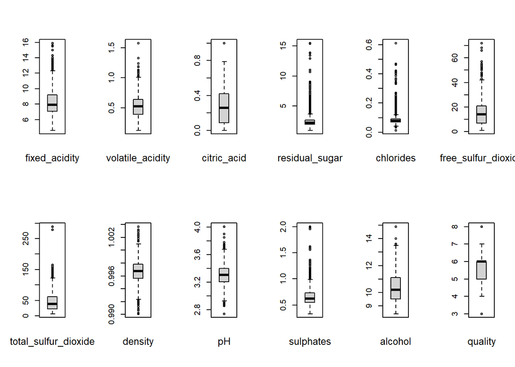

```r
# Estructura general gráfica 2 filas, 6 columnas
oldpar = par(mfrow = c(2,6))

#Realización de las distintas gráficas boxplot
for ( i in 1:12 ) {
  boxplot(df[[i]])
  mtext(names(df)[i], cex = 0.8, side = 1, line = 2)
}
```

```r
boxplot.stats(df$fixed_acidity)$out
```

```
##  [1] 12.8 12.8 15.0 15.0 12.5 13.3 13.4 12.4 12.5 13.8 13.5 12.6 12.5 12.8 12.8
## [16] 14.0 13.7 13.7 12.7 12.5 12.8 12.6 15.6 12.5 13.0 12.5 13.3 12.4 12.5 12.9
## [31] 14.3 12.4 15.5 15.5 15.6 13.0 12.7 13.0 12.7 12.4 12.7 13.2 13.2 13.2 15.9
## [46] 13.3 12.9 12.6 12.6
```

```r
boxplot.stats(df$volatile_acidity)$out
```

```
##  [1] 1.130 1.020 1.070 1.330 1.330 1.040 1.090 1.040 1.240 1.185 1.020 1.035
## [13] 1.025 1.115 1.020 1.020 1.580 1.180 1.040
```

```r
boxplot.stats(df$citric_acid)$out
```

```
## [1] 1
```

```r
boxplot.stats(df$residual_sugar)$out
```

```
##   [1]  6.10  6.10  3.80  3.90  4.40 10.70  5.50  5.90  5.90  3.80  5.10  4.65
##  [13]  4.65  5.50  5.50  5.50  5.50  7.30  7.20  3.80  5.60  4.00  4.00  4.00
##  [25]  4.00  7.00  4.00  4.00  6.40  5.60  5.60 11.00 11.00  4.50  4.80  5.80
##  [37]  5.80  3.80  4.40  6.20  4.20  7.90  7.90  3.70  4.50  6.70  6.60  3.70
##  [49]  5.20 15.50  4.10  8.30  6.55  6.55  4.60  6.10  4.30  5.80  5.15  6.30
##  [61]  4.20  4.20  4.60  4.20  4.60  4.30  4.30  7.90  4.60  5.10  5.60  5.60
##  [73]  6.00  8.60  7.50  4.40  4.25  6.00  3.90  4.20  4.00  4.00  4.00  6.60
##  [85]  6.00  6.00  3.80  9.00  4.60  8.80  8.80  5.00  3.80  4.10  5.90  4.10
##  [97]  6.20  8.90  4.00  3.90  4.00  8.10  8.10  6.40  6.40  8.30  8.30  4.70
## [109]  5.50  5.50  4.30  5.50  3.70  6.20  5.60  7.80  4.60  5.80  4.10 12.90
## [121]  4.30 13.40  4.80  6.30  4.50  4.50  4.30  4.30  3.90  3.80  5.40  3.80
## [133]  6.10  3.90  5.10  5.10  3.90 15.40 15.40  4.80  5.20  5.20  3.75 13.80
## [145] 13.80  5.70  4.30  4.10  4.10  4.40  3.70  6.70 13.90  5.10  7.80
```

```r
boxplot.stats(df$chlorides)$out
```

```
##   [1] 0.176 0.170 0.368 0.341 0.172 0.332 0.464 0.401 0.467 0.122 0.178 0.146
##  [13] 0.236 0.610 0.360 0.270 0.039 0.337 0.263 0.611 0.358 0.343 0.186 0.213
##  [25] 0.214 0.121 0.122 0.122 0.128 0.120 0.159 0.124 0.122 0.122 0.174 0.121
##  [37] 0.127 0.413 0.152 0.152 0.125 0.122 0.200 0.171 0.226 0.226 0.250 0.148
##  [49] 0.122 0.124 0.124 0.143 0.222 0.039 0.157 0.422 0.034 0.387 0.415 0.157
##  [61] 0.157 0.243 0.241 0.190 0.132 0.126 0.038 0.165 0.145 0.147 0.012 0.012
##  [73] 0.039 0.194 0.132 0.161 0.120 0.120 0.123 0.123 0.414 0.216 0.171 0.178
##  [85] 0.369 0.166 0.166 0.136 0.132 0.132 0.123 0.123 0.123 0.403 0.137 0.414
##  [97] 0.166 0.168 0.415 0.153 0.415 0.267 0.123 0.214 0.214 0.169 0.205 0.205
## [109] 0.039 0.235 0.230 0.038
```

```r
boxplot.stats(df$free_sulfur_dioxide)$out
```

```
##  [1] 52 51 50 68 68 43 47 54 46 45 53 52 51 45 57 50 45 48 43 48 72 43 51 51 52
## [26] 55 55 48 48 66
```

```r
boxplot.stats(df$total_sulfur_dioxide)$out
```

```
##  [1] 145 148 136 125 140 136 133 153 134 141 129 128 129 128 143 144 127 126 145
## [20] 144 135 165 124 124 134 124 129 151 133 142 149 147 145 148 155 151 152 125
## [39] 127 139 143 144 130 278 289 135 160 141 141 133 147 147 131 131 131
```

```r
boxplot.stats(df$density)$out
```

```
##  [1] 0.99160 0.99160 1.00140 1.00150 1.00150 1.00180 0.99120 1.00220 1.00220
## [10] 1.00140 1.00140 1.00140 1.00140 1.00320 1.00260 1.00140 1.00315 1.00315
## [19] 1.00315 1.00210 1.00210 0.99170 0.99220 1.00260 0.99210 0.99154 0.99064
## [28] 0.99064 1.00289 0.99162 0.99007 0.99007 0.99020 0.99220 0.99150 0.99157
## [37] 0.99080 0.99084 0.99191 1.00369 1.00369 1.00242 0.99182 1.00242 0.99182
```

```r
boxplot.stats(df$pH)$out
```

```
##  [1] 3.90 3.75 3.85 2.74 3.69 3.69 2.88 2.86 3.74 2.92 2.92 2.92 3.72 2.87 2.89
## [16] 2.89 2.92 3.90 3.71 3.69 3.69 3.71 3.71 2.89 2.89 3.78 3.70 3.78 4.01 2.90
## [31] 4.01 3.71 2.88 3.72 3.72
```

```r
boxplot.stats(df$sulphates)$out
```

```
##  [1] 1.56 1.28 1.08 1.20 1.12 1.28 1.14 1.95 1.22 1.95 1.98 1.31 2.00 1.08 1.59
## [16] 1.02 1.03 1.61 1.09 1.26 1.08 1.00 1.36 1.18 1.13 1.04 1.11 1.13 1.07 1.06
## [31] 1.06 1.05 1.06 1.04 1.05 1.02 1.14 1.02 1.36 1.36 1.05 1.17 1.62 1.06 1.18
## [46] 1.07 1.34 1.16 1.10 1.15 1.17 1.17 1.33 1.18 1.17 1.03 1.17 1.10 1.01
```

```r
boxplot.stats(df$alcohol)$out
```

```
##  [1] 14.00000 14.00000 14.00000 14.00000 14.90000 14.00000 13.60000 13.60000
##  [9] 13.60000 14.00000 14.00000 13.56667 13.60000
```

```r
boxplot.stats(df$quality)$out
```

```
##  [1] 8 8 8 8 8 3 8 8 8 3 8 3 8 3 3 8 8 8 8 8 3 3 8 8 3 3 3 8
```

Después de su análisis, las variables ‘volatile_acidity’, ‘chlorides’, ‘total_sulfur_dioxide’ y ‘sulphates’ muestran valores extremos muy alejados. En este caso, se podrían dar es decir, estos valores podrían ser reproducibles en otros vinos y pueden tener significado, ya que por ejemplo valores elevados de ácidos volatiles (’volatile_acidity) o sulfitos (total_sulfur_dioxide) se relacionarían con una baja calidad del vino.

## 2.4. Análisis de datos

### 2.4.1. Selección de los grupos de datos que se quieren analizar/comparar (planificación de los análisis a aplicar)

Inicialmente se utilitzarán todas las variables del dataset para el análisis estadístico. También se tendrán en cuenta distintos grupos a partir de la variable calidad, donde el grado/grupo de calidad quedaría definida como: calidad Muy Baja MB=3, Baja B=4. Media M=5, Buena G=6, Muy Buena VG=7 y excelente E=8. Con estos grupos, se podrán realizar distintos tests de hipótesis.

```r
#Agrupación según la calidad del vino
#df$gruposcalidad[df$quality==3]<-'3MB'
#df$gruposcalidad[df$quality==4]<-'4B'
#df$gruposcalidad[df$quality==5]<-'5M'
#df$gruposcalidad[df$quality==6]<-'6G'
#Tdf$gruposcalidad[df$quality==7]<-'7VG'
#df$gruposcalidad[df$quality==8]<-'8E'

#df$gruposcalidad<-factor(df$gruposcalidad)

#Cantidad de muestras según los grupos de calidad
table(df$quality)
```

```
##
##   3   4   5   6   7   8
##  10  53 681 638 199  18
```

Se puede observar en la tabla de agrupación ‘quality’, que los grupos de las calidades más extremas (3MB y 8E) son inferiores a 20 muestras. Estos datos se tendrán en cuenta a la hora de hacer los test de hipótesis.

Para el resto de atributos del dataset se buscarán si hay correlaciones entre ellos y se intentará realizar un modelo de regresión lineal con el objetivo de determinar la calidad del vino segun los distintos parámetros.

### 2.4.2. Comprobación de la normalidad y homogeneidad de la varianza

Para la comprobación de la normalidad de los datos, primero se haràn distintos histogramas de las variables para tener un primera visualización de su distribución.

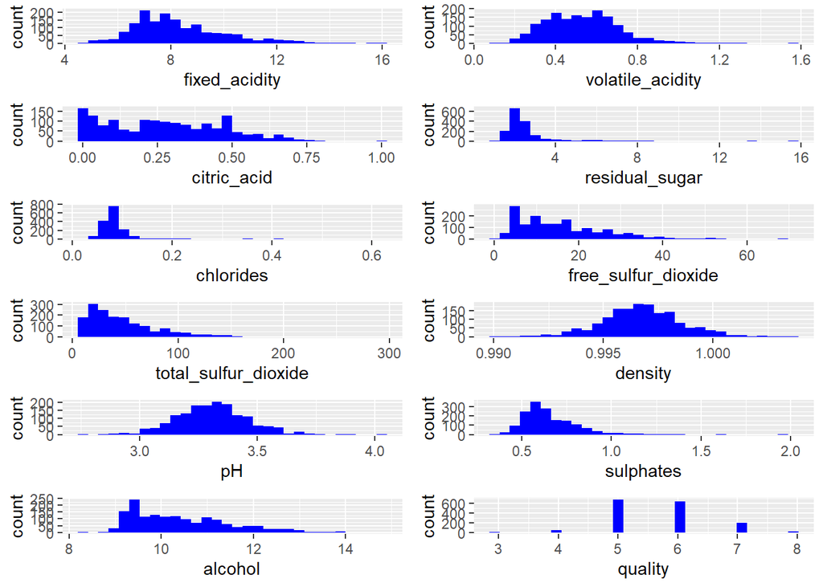

```r
p1<-ggplot(df, aes(x = fixed_acidity)) + geom_histogram(fill = "blue")
p2<-ggplot(df, aes(x = volatile_acidity)) + geom_histogram(fill = "blue")
p3<-ggplot(df, aes(x = citric_acid)) + geom_histogram(fill = "blue")
p4<-ggplot(df, aes(x = residual_sugar)) + geom_histogram(fill = "blue")
p5<-ggplot(df, aes(x = chlorides)) + geom_histogram(fill = "blue")
p6<-ggplot(df, aes(x = free_sulfur_dioxide)) + geom_histogram(fill = "blue")
p7<-ggplot(df, aes(x = total_sulfur_dioxide)) + geom_histogram(fill = "blue")
p8<-ggplot(df, aes(x = density)) + geom_histogram(fill = "blue")
p9<-ggplot(df, aes(x = pH)) + geom_histogram(fill = "blue")
p10<-ggplot(df, aes(x = sulphates)) + geom_histogram(fill = "blue")
p11<-ggplot(df, aes(x = alcohol)) + geom_histogram(fill = "blue")
p12<-ggplot(df, aes(x = quality)) + geom_histogram(fill = "blue")

grid.arrange(p1, p2, p3, p4, p5, p6, p7, p8, p9, p10, p11, p12, nrow = 6)
```

Como se puede observar, pocas de las variables podrían seguir una distribución normal, entre ellas podrían ser ‘volatile_acidity’, ‘density’ y ‘pH’. Con el objetivo de verificar la suposición de la normalidad, se realizarán los tests de **Shapiro-Wilk** y de **Kolmogorov-Smirnov** para estas variables.

```r
#Comprobación de la normalidad por Shapiro.test
shapiro.test(df$volatile_acidity)
```

```
##
##  Shapiro-Wilk normality test
##
## data:  df$volatile_acidity
## W = 0.97434, p-value = 2.693e-16
```

```r
shapiro.test(df$density)
```

```
##
##  Shapiro-Wilk normality test
##
## data:  df$density
## W = 0.99087, p-value = 1.936e-08
```

```r
shapiro.test(df$pH)
```

```
##
##  Shapiro-Wilk normality test
##
## data:  df$pH
## W = 0.99349, p-value = 1.712e-06
```

```r
shapiro.test(df$quality)
```

```
##
##  Shapiro-Wilk normality test
##
## data:  df$quality
## W = 0.85759, p-value < 2.2e-16
```

```r
ks.test(df$volatile_acidity, pnorm, mean(df$volatile_acidity), sd(df$volatile_acidity))
```

```
##
##  One-sample Kolmogorov-Smirnov test
##
## data:  df$volatile_acidity
## D = 0.054662, p-value = 0.0001416
## alternative hypothesis: two-sided
```

```r
ks.test(df$density, pnorm, mean(df$density), sd(df$density))
```

```
##
##  One-sample Kolmogorov-Smirnov test
##
## data:  df$density
## D = 0.044787, p-value = 0.003274
## alternative hypothesis: two-sided
```

```r
ks.test(df$pH, pnorm, mean(df$pH), sd(df$pH))
```

```
##
##  One-sample Kolmogorov-Smirnov test
##
## data:  df$pH
## D = 0.040368, p-value = 0.01091
## alternative hypothesis: two-sided
```

```r
ks.test(df$quality, pnorm, mean(df$quality), sd(df$quality))
```

```
##
##  One-sample Kolmogorov-Smirnov test
##
## data:  df$quality
## D = 0.24982, p-value < 2.2e-16
## alternative hypothesis: two-sided
```

Como se puede observar en los tests Shapiro-Wilk y Kolmogorov-Smirnov, los valores p-value obtenidos han sido inferiores a alpha=0.05 (nivel de significancia) indicancdo que la hipótesis nula es rechazada y por tanto los datos no cuentan con una distribución normal. Se verificarán también para el resto de variables con una adaptación de la función que planteó T. Gutiérrez (2017).

```r
alpha = 0.05
col.names = colnames(df)
for (i in 1:ncol(df)) {
  if (i == 1) cat("Variables que no siguen una distribución normal:\n")
  if (is.integer(df[,i]) | is.numeric(df[,i])) {
    p_val = shapiro.test(df[,i])$p.value
    if (p_val < alpha) {
    cat(col.names[i])
    # Format output
    if (i < ncol(df) - 1) cat(", ")
    if (i %% 3 == 0) cat("\n")
    }
  }
}
```

```
## Variables que no siguen una distribución normal:
## fixed_acidity, volatile_acidity, citric_acid,
## residual_sugar, chlorides, free_sulfur_dioxide,
## total_sulfur_dioxide, density, pH,
## sulphates, alcoholquality
```

Como se puede verificar todas la variables no siguen una distribución normal. Para el test de homogeneidad de las varianzas se aplicará el test de **Fligner-Killeen** ya que los datos no siguen la distribución normal. En este test, la hipótesis nula asume igualdad de varianzas en los diferentes grupos de datos, por lo que p-valores inferiores al nivel de significancia indicarán heterocedasticidad. En este caso, se aplicará el test para las variables ‘volatile_acidity’ y ‘citric_acidity’ con los distintos grupos de la variable ‘quality’.

```r
fligner.test(volatile_acidity ~ quality, data = df)
```

```
##
##  Fligner-Killeen test of homogeneity of variances
##
## data:  volatile_acidity by quality
## Fligner-Killeen:med chi-squared = 30.826, df = 5, p-value = 1.014e-05
```

```r
fligner.test(citric_acid ~ quality, data = df)
```

```
##
##  Fligner-Killeen test of homogeneity of variances
##
## data:  citric_acid by quality
## Fligner-Killeen:med chi-squared = 10.916, df = 5, p-value = 0.05307
```

En el primero de los casos, acidez volátil con los grupos de calidad, se rechaza la hipótesis nula de homocedasticidad ya que el valor p-value es inferior a 0.05 y por lo tanto la variable ‘volatile_acidity’ presenta varianzas estadísticamente diferentes para los grupos de ‘quality’. En cambio para ácido cítrico con los grupos de calidad, el valor p-value es superior a 0.05, estonces las varianzas de estos grupos son similares.

### 2.4.3. Análisis estadístico

Se empezará el análisis estadístico de forma introductoria con el análisis estadístico descriptivo, ya que no se hizo en los anteriores apartados. También se realizarán tres pruebas estadísticas para intentar resolver las cuestiones o problemas planteados inicialmente.

#### 2.4.3.0. Análisis estadístico descriptivo

```r
summary (df)
```

```
##  fixed_acidity   volatile_acidity  citric_acid    residual_sugar
##  Min.   : 4.60   Min.   :0.1200   Min.   :0.000   Min.   : 0.900
##  1st Qu.: 7.10   1st Qu.:0.3900   1st Qu.:0.090   1st Qu.: 1.900
##  Median : 7.90   Median :0.5200   Median :0.260   Median : 2.200
##  Mean   : 8.32   Mean   :0.5278   Mean   :0.271   Mean   : 2.539
##  3rd Qu.: 9.20   3rd Qu.:0.6400   3rd Qu.:0.420   3rd Qu.: 2.600
##  Max.   :15.90   Max.   :1.5800   Max.   :1.000   Max.   :15.500
##    chlorides       free_sulfur_dioxide total_sulfur_dioxide    density
##  Min.   :0.01200   Min.   : 1.00       Min.   :  6.00       Min.   :0.9901
##  1st Qu.:0.07000   1st Qu.: 7.00       1st Qu.: 22.00       1st Qu.:0.9956
##  Median :0.07900   Median :14.00       Median : 38.00       Median :0.9968
##  Mean   :0.08747   Mean   :15.87       Mean   : 46.47       Mean   :0.9967
##  3rd Qu.:0.09000   3rd Qu.:21.00       3rd Qu.: 62.00       3rd Qu.:0.9978
##  Max.   :0.61100   Max.   :72.00       Max.   :289.00       Max.   :1.0037
##        pH          sulphates         alcohol         quality
##  Min.   :2.740   Min.   :0.3300   Min.   : 8.40   Min.   :3.000
##  1st Qu.:3.210   1st Qu.:0.5500   1st Qu.: 9.50   1st Qu.:5.000
##  Median :3.310   Median :0.6200   Median :10.20   Median :6.000
##  Mean   :3.311   Mean   :0.6581   Mean   :10.42   Mean   :5.636
##  3rd Qu.:3.400   3rd Qu.:0.7300   3rd Qu.:11.10   3rd Qu.:6.000
##  Max.   :4.010   Max.   :2.0000   Max.   :14.90   Max.   :8.000
```

Como se puede observar en el análisis estadístico las variables ‘residual_sugar’, ‘free_sulfur_dioxide’, ‘total_sulfur_dioxide’ se comfirma que tienen valores muy lejanos de los que podrían esperarse (sobretodo la variable total_sulfur_dioxide). Otro dato importante a analizar es la variable ‘quality’ en que se observa que la media de los vinos se encuentra en 5.636.Esto nos da una idea que en gran parte los vinos que se analiza son de un rango medio.

#### 2.4.3.1. Correlación entre variables

Se realizará la correlación de las distintas variables entre todas ellas, mediante el test de correlación **Spearman**, ya que las variables del estudio no siguen una distribución normal, en caso de que la hubieran seguido una distribución normal se hubiera aplicado la correlción de **Pearson**. Para determinar la correlación se utilizará la función cor() con el método ‘Spearman’, y se mostrarán los resultados con una figura en círculos y sus valores. Cuando mayor sean los circulos, mayor será su correlación. Y según su color, la correlación será positiva si es azul, y negativa si es roja. Respeto a los valores numéricos de la correlación, cuando más cercanos a +1 o -1 mayor será su correlación.

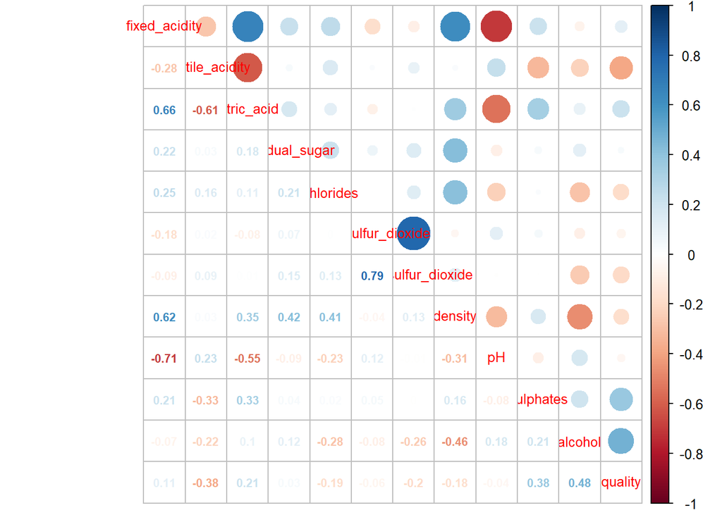

```r
corr.res<-cor(df, method="spearman")
corrplot.mixed(corr.res,upper="circle",number.cex=.7,tl.cex=.8)
```

Para la variable de más interés ‘quality’, los valores de correlación han sido reativamente muy bajos, en que el coeficiente de dicha variable con la variable alcohol ha sido de 0.48, con ‘volatile_acidity’ -0.38 y con ‘sulphates’ de 0.38. Una de los motivos por el cual la correlación de las distintas variables con la variable calidad tengan valores bajos, podría ser que ‘quality’ sea de tipo entero y por tanto su rango de valores dentro de un mismo grupo no se muy elevado y en consecuencia no haya una nube de puntos muy definida.

A modo resumen se mostrarán la disposición de las muestras segun las variables ‘fixed_acidity’, ‘citric_acid’, ‘density’ y ‘pH’, con ello se puede observar las tendencias positivas y negativas de las relaciones entre variables.

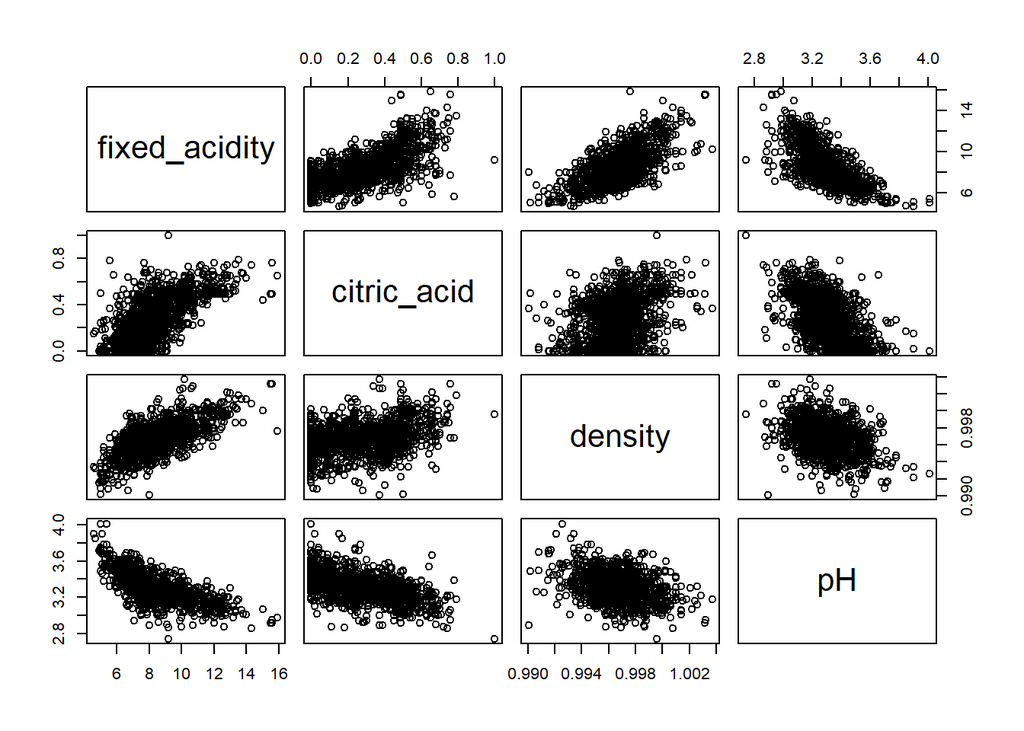

```r
df2<-subset(df, select=c(1,3,8,9))
pairs(df2[, colnames(df2)])
```

#### 2.4.3.2. Tests hipótesis

Se realizarán distintos tests de hipótesis con el objetivo de resolver distintas cuestiones que se han planteado.

> ¿La calidad del vino es superior si éste tiene menos contenido de acidos volatiles?

Para resolver esta cuestión se hará un test de hipótesis de dos muestras donde se comparan la distintas medias de cada una de ellas. Las muestras que se escogeran son el contenido de acidez volátil en función de su calidad. En total se podrían realizar 6 grupos segun su calidad, tal y como vimos en la selección de grupos (apartado 2.4.1). Debido a que los grupos que tienen calidad 3 y 8 son inferiores a 30 muestras, estos no se podrán utilizar para el contraste de hipótesis.

```r
va4<-df$volatile_acidity[df$quality==4]
va5<-df$volatile_acidity[df$quality==5]
va6<-df$volatile_acidity[df$quality==6]
va7<-df$volatile_acidity[df$quality==7]
```

Una vez realizado los distintos grupos se realizará un test de hipótesis, comparando una muestra de menor calidad, con la de máxima calidad (habrá un total de tres)

```
Contraste de hipótesis de dos muestras (ácidos volátiles según calidad)

            H0 : µ1 = µ2  (Hipótesis nula)

            H1 : µ1 > µ2  (Hipótesis alternativa)

Donde µ1 es la media de ácidos volátiles para vinos de menor calidad y µ2 es la media para vinos de mayor calidad (en todos los casos, ésta será siempre la de calidad 7).
La hipótesis nula será que las dos medias sean iguales, en caso de no aceptar la hipótesis nula, la media de peor calidad será superior.
```

También se aprovechará para verificar el test de varianzas (homogeneidad)

```r
#verificación del test de varianzas
var.test(va4, va7)
```

```
##
##  F test to compare two variances
##
## data:  va4 and va7
## F = 2.2972, num df = 52, denom df = 198, p-value = 4.29e-05
## alternative hypothesis: true ratio of variances is not equal to 1
## 95 percent confidence interval:
##  1.528008 3.652087
## sample estimates:
## ratio of variances
##            2.29721
```

```r
#test hipótesis acidez volatil -- calidad
t.test(va4, va7, alternative="greater", var.equal=FALSE)
```

```
##
##  Welch Two Sample t-test
##
## data:  va4 and va7
## t = 9.0811, df = 64.529, p-value = 1.9e-13
## alternative hypothesis: true difference in means is greater than 0
## 95 percent confidence interval:
##  0.2367424       Inf
## sample estimates:
## mean of x mean of y
## 0.6939623 0.4039196
```

```r
t.test(va5, va7, alternative="greater", var.equal=FALSE)
```

```
##
##  Welch Two Sample t-test
##
## data:  va5 and va7
## t = 14.334, df = 360.21, p-value < 2.2e-16
## alternative hypothesis: true difference in means is greater than 0
## 95 percent confidence interval:
##  0.1532048       Inf
## sample estimates:
## mean of x mean of y
## 0.5770411 0.4039196
```

```r
t.test(va6, va7, alternative="greater", var.equal=FALSE)
```

```
##
##  Welch Two Sample t-test
##
## data:  va6 and va7
## t = 7.7279, df = 362.28, p-value = 5.432e-14
## alternative hypothesis: true difference in means is greater than 0
## 95 percent confidence interval:
##  0.07359872        Inf
## sample estimates:
## mean of x mean of y
## 0.4974843 0.4039196
```

Como se pueden observar en los resultados, las medias de los distintos grupos analizados son distintas ya que el valor p-value del test ha sido en todos los casos inferior a alpha:0.05, por lo tanto no se acepta la hipótesis nula y la media de ácidos volátiles del grupo de peor calidad será superior al de mayor calidad. También se confirma que las dos varianzas de las muestras no son iguales.

Estos resultados nos pueden permitir diferenciar las calidades según la cantidad de ácidos volatiles que tenga el vino, y por lo tanto, podría ser una de las variables clave para la modelización.

> ¿La calidad del vino es superior si éste tiene más contenido de ácido cítrico?

Se procederá a realizar los grupos de ácido cítrico segun la calidad del vino, igual que se hizo en la pregunta anterior.

```r
ca4<-df$citric_acid[df$quality==4]
ca5<-df$citric_acid[df$quality==5]
ca6<-df$citric_acid[df$quality==6]
ca7<-df$citric_acid[df$quality==7]
```

```
Contraste de hipótesis de dos muestras (ácido cítrico según calidad)

            H0 : µ1 = µ2  (Hipótesis nula)

            H1 : µ1 < µ2  (Hipótesis alternativa)

Donde µ1 es la media de ácido cítrico para vinos de menor calidad y µ2 es la media de mayor calidad (en todos los casos, ésta será siempre la de calidad 7).
La hipótesis nula será que las dos medias sean iguales, en caso de no aceptar la hipótesis nula, la media de peor calidad será inferior.
```

```r
#test de varianzas
var.test(ca4, ca7)
```

```
##
##  F test to compare two variances
##
## data:  ca4 and ca7
## F = 1.069, num df = 52, denom df = 198, p-value = 0.7285
## alternative hypothesis: true ratio of variances is not equal to 1
## 95 percent confidence interval:
##  0.7110692 1.6995240
## sample estimates:
## ratio of variances
##           1.069023
```

```r
#test hipótesis ácido cítrico -- calidad
t.test(ca4, ca7, alternative="less", var.equal=FALSE)
```

```
##
##  Welch Two Sample t-test
##
## data:  ca4 and ca7
## t = -6.5136, df = 79.836, p-value = 3.021e-09
## alternative hypothesis: true difference in means is less than 0
## 95 percent confidence interval:
##       -Inf -0.149665
## sample estimates:
## mean of x mean of y
## 0.1741509 0.3751759
```

En este caso sólo se hizo el test de hipótesis para los grupos de peor calidad y el de mayor calidad. Se rechazo la hipótesis nula, ya que el valor de p-value fue inferior a 0.05, y se acepta que la media de ácido cítrico es inferior para los vinos de menor calidad respeto a los de mayor calidad. También se verificó la igualdad de varianzas entre los dos grupos.

> ¿La calidad del vino es superior si éste tiene más contenido de alcohol?

Se procederá a realizar los grupos de alcohol segun la calidad del vino, igual que se hizo en la pregunta anterior.

```r
a4<-df$alcohol[df$quality==4]
a5<-df$alcohol[df$quality==5]
a6<-df$alcohol[df$quality==6]
a7<-df$alcohol[df$quality==7]
```

```
Contraste de hipótesis de dos muestras (alcohol según calidad)

            H0 : µ1 = µ2  (Hipótesis nula)

            H1 : µ1 < µ2  (Hipótesis alternativa)

Donde µ1 es la media alcohol para vinos de menor calidad (en todos los casos, ésta será siempre la de calidad 4) y µ2 es la media de mayor calidad .
La hipótesis nula será que las dos medias sean iguales, en caso de no aceptar la hipótesis nula, la media de peor calidad será inferior.
```

```r
#test de varianzas
var.test(a4, a7)
```

```
##
##  F test to compare two variances
##
## data:  a4 and a7
## F = 0.94433, num df = 52, denom df = 198, p-value = 0.8299
## alternative hypothesis: true ratio of variances is not equal to 1
## 95 percent confidence interval:
##  0.6281313 1.5012945
## sample estimates:
## ratio of variances
##          0.9443337
```

```r
#test hipótesis alcohol -- calidad
t.test(a4, a5, alternative="less", var.equal=FALSE)
```

```
##
##  Welch Two Sample t-test
##
## data:  a4 and a5
## t = 2.7793, df = 57.136, p-value = 0.9963
## alternative hypothesis: true difference in means is less than 0
## 95 percent confidence interval:
##       -Inf 0.5851954
## sample estimates:
## mean of x mean of y
## 10.265094  9.899706
```

```r
t.test(a4, a6, alternative="less", var.equal=FALSE)
```

```
##
##  Welch Two Sample t-test
##
## data:  a4 and a6
## t = -2.7003, df = 63.407, p-value = 0.004437
## alternative hypothesis: true difference in means is less than 0
## 95 percent confidence interval:
##        -Inf -0.1391467
## sample estimates:
## mean of x mean of y
##  10.26509  10.62952
```

```r
t.test(a4, a7, alternative="less", var.equal=FALSE)
```

```
##
##  Welch Two Sample t-test
##
## data:  a4 and a7
## t = -8.2596, df = 83.719, p-value = 9.351e-13
## alternative hypothesis: true difference in means is less than 0
## 95 percent confidence interval:
##       -Inf -0.959006
## sample estimates:
## mean of x mean of y
##  10.26509  11.46591
```

En este caso, los distintos tests mostraron distintos resultados, ya que la comparación entre los grupos a4 y a5, se tuvo que aceptar la hipótesis nula ya que la media de alcohol fue en la calidad inferior(calidad 4) fue superior a la calidad media (5). En cambio para el resto de tests, si que se rechazó la hipótesis nula y se aceptó que el contenido de alcohol era inferior.

#### 2.4.3.3. Modelo predictivo regresión lineal

Por último y como objetivo final de la práctica, se realizará distintos modelos de regresión lineal que permita predir la calidad de un vino a partir de los distintos atributos analizados (todos ellos son regresores cuantitativos).

```r
#Generación de modelos
#Modelo 1 con tres variables independientes
modelo1<- lm(quality ~ alcohol + volatile_acidity + sulphates, data = df)
modelo2<- lm(quality ~ volatile_acidity + sulphates + total_sulfur_dioxide + alcohol, data = df)
modelo3<- lm(quality ~ volatile_acidity + sulphates + chlorides + total_sulfur_dioxide + alcohol + pH, data = df)
```

```r
# Tabla con los coeficientes de determinación de cada modelo
tab.coeficientes <- matrix(c(1, summary(modelo1)$r.squared,
                              2, summary(modelo2)$r.squared,
                              3, summary(modelo3)$r.squared),
                              ncol = 2, byrow = TRUE)
colnames(tab.coeficientes) <- c("Modelo", "R^2")
tab.coeficientes
```

```
##      Modelo       R^2
## [1,]      1 0.3358973
## [2,]      2 0.3437824
## [3,]      3 0.3571736
```

```r
x1<-data.frame(volatile_acidity=0.25, sulphates=0.45, chlorides=0.08, total_sulfur_dioxide=0.4, alcohol=14.5, pH=2.9)
x2<-data.frame(volatile_acidity=1.4, sulphates=2.01, chlorides=0.45, total_sulfur_dioxide=150, alcohol=10, pH=3.7)

predict(modelo3, x1)
```

```
##        1
## 7.227697
```

```r
predict(modelo3, x2)
```

```
##       1
## 4.66822
```

# 4. Conclusión

# 5. Bibliografía

[Cortez et al., 2009]

J. Gibergans (2018) Regresión lineal simple. Universitat Oberta de Catalunya

J. Gibergans (2018) Regresión lineal múltiple. Universitat Oberta de Catalunya

T. Gutiérrez (2017) Práctica 2: Limpieza y validación de los datos

D. Liviano y M. Pujol (2019) Análisis de datos y estadística con R y R-commander. Universitat Oberta de Catalunya.

D. Liviano y M. Pujol (2019) Modelos de regresión y análisis multivarible con R-commander. Universitat Oberta de Catalunya.

L. Subirats, D.O. Oswaldo, M. Calvo (2019) Introducción a la limpieza y análisis de los datos. Universitat Oberta de Catalunya